# Limpieza y organización de los datos del #MenstruScrapper

Datos de Marzo 2022

[figure not shown]

## Presentación

En [nuestro repositorio](https://github.com/Ecofeminita/EcoFemiData/tree/master/MenstruAccion/cuanto_cuesta_menstruar) se encuentran aclaradas todas las fuentes adicionales a las que se recurrió para realizar el cálculo y los archivos correspondientes. En otro paso se encuentra el cálculo propiamente dicho del costo anual de menstruar.

## Preparando el entorno de trabajo

Comenzamos levantando las librerías necesarias, cargando los datos srappeados desde el archivo .csv, y un diccionario que indica a qué región pertenece cada provincia del país.

```r
library(EnvStats)
library(tidyverse)
library(ggridges)
library(openxlsx)
library(viridis)
library(readxl)
library(magrittr)
library(scales)
library(kableExtra)

datos <- read.csv("Fuentes/precios-gestion-menstrual-2022-03-13.csv",
                  header = TRUE, sep = ",", dec = ".",
                  fill = TRUE, encoding = "UTF-8")

regiones <- openxlsx::read.xlsx("Fuentes/provincias_regiones.xlsx")
```

Vista previa del dataset:

```r
head(datos)
```

|  | Categoría | Marca | Nombre | Presentación | Comercio | Sucursal | Dirección | Localidad | Provincia | Precio.de.lista |
| --- | --- | --- | --- | --- | --- | --- | --- | --- | --- | --- |
| 1 | tampones | NOSOTRAS | Tampon Digi Mini Nosotras 8 Un | 8.0 un | Jumbo Retail Argentina S.A. | SM 140 Orán - Salta. | 20 De Febrero Esq. Guemes 0 | ORAN | Salta | 112 |
| 2 | tampones | EQUATE | Tampon Higienico Mujer Equate Medio 20 Un | 20.0 un | Wal Mart Argentina S.R.L. | Salta Ciudad Judicial | Avenida Fuerza Aerea Esq. Aguas Blancas | BARRIO CASTAÑARES | Salta | 339 |
| 3 | tampones | EQUATE | Tampon Higienico Mujer Equate Medio 20 Un | 20.0 un | Wal Mart Argentina S.R.L. | Salta | Av Paraguay 1450 | SALTA | Salta | 339 |
| 4 | tampones | EQUATE | Tampon Higienico Mujer Equate Super 20 Un | 20.0 un | Wal Mart Argentina S.R.L. | Salta | Av Paraguay 1450 | SALTA | Salta | 285 |
| 5 | tampones | KOTEX | Tampon Kotex 8 Un | 8.0 un | Jumbo Retail Argentina S.A. | Salta V. | Florida 50 | SALTA | Salta | 208 |
| 6 | tampones | FARMACITY | Tampon Medio Farmacity Enjoy 8 Un | 8.0 un | Farmacity S.A. | SALPeatonal [Alberdi 84] | Alberdi 84 | Salta | Salta | 105 |

Vista previa del diccionario de regiones:

```r
head(regiones)
```

|  | Provincia | Region |
| --- | --- | --- |
| 1 | Buenos Aires | GBA |
| 2 | CABA | GBA |
| 3 | Mendoza | CUY |
| 4 | Córdoba | PAM |
| 5 | Río Negro | PAT |
| 6 | Neuquén | PAT |

Definimos una pequeña función: `cant` nos va a devolver un número en formato character (texto), con cero dígitos, con un punto para separar los miles, y una coma para separar los decimales.

```r
cant <- function(x){
  format(x, digits = 0, big.mark = ".", decimal.mark = ",")}
```

Guardamos el valor de la fecha a la que corresponde el ejercicio.

```r
date <- "Marzo 2022"
```

## Exploración de los datos

Al dataframe `datos` le pegamos los valores de las regiones, usando como variable de identificación a la `Provincia`. A continuación podemos borrar de nuestro entorno de trabajo el elemento `regiones`.

```r
datos <- left_join(datos, regiones, by = "Provincia")
rm(regiones)
```

`datos` cuenta con 32.510 observaciones. A su vez, podemos ver con qué variables contamos en el dataset:

```r
names(datos)
```

```
##  [1] "Categoría"       "Marca"           "Nombre"          "Presentación"
##  [5] "Comercio"        "Sucursal"        "Dirección"       "Localidad"
##  [9] "Provincia"       "Precio.de.lista" "Region"
```

A continuación, exploraremos el comportamiento de las diferentes variables. Con `count()` pedimos un conteo de observaciones para cada valor que toma la variable aclarada, con `arrange()` ordenamos los datos de forma decreciente según el conteo anterior, y en `mutate()` se definen nuevas variables para nuestro cuadro. Por ejemplo, el porcentaje es la cantidad de cada categoría sobre la suma de las mismas, expresada en formato de porcentaje.

### Categorías

```r
datos %>%
  count(Categoría) %>%
  arrange(-n) %>%
  mutate(porcentaje = percent(n/sum(n)))
```

| Categoría | n | porcentaje |
| --- | --- | --- |
| toallitas | 24142 | 74% |
| tampones | 8368 | 26% |

Cabe destacar que esta composición corresponde a la disponibilidad de precios, no refleja la estructura del consumo. O sea, no podemos decir que se consumen en un 74% toallitas y en 26% tampones. Lo que sí sabemos es que tenemos una muestra muy grande de precios para ambas categorías, aunque debemos tener en cuenta que la página de Precios Claros puede tener un sesgo por no incluir los comercios tradicionales sino únicamente grandes cadenas.

### Marcas

```r
datos %>%
  count(Marca) %>%
  arrange(-n) %>%
  mutate(porcentaje = n/sum(n),
         acumulado = cumsum(porcentaje),
         porcentaje = percent(porcentaje),
         acumulado = percent(acumulado))
```

| Marca | n | porcentaje | acumulado |
| --- | --- | --- | --- |
| KOTEX | 7655 | 23.5466% | 23.5466% |
| BONTÉ | 6215 | 19.1172% | 42.6638% |
| LADYSOFT | 4721 | 14.5217% | 57.1855% |
| SIEMPRE LIBRE | 2320 | 7.1363% | 64.3217% |
| FARMACITY | 2101 | 6.4626% | 70.7844% |
| O.B. | 1323 | 4.0695% | 74.8539% |
| NOSOTRAS | 1162 | 3.5743% | 78.4282% |
| LINA | 1141 | 3.5097% | 81.9379% |
| ALWAYS | 1084 | 3.3344% | 85.2722% |
| TAMPAX | 765 | 2.3531% | 87.6253% |

[output cut: 17 more lines]

Contamos con 27 marcas de productos, aunque con 12 de ellas se completa el 90% del total de productos. Las primeras 3 marcas concentran más de la mitad de las observaciones. Nuevamente aquí hay que tener en cuenta que no se trata exactamente de una “concentración de mercado”.

### Presentación

```r
datos %>%
  count(Presentación) %>%
  arrange(-n) %>%
  mutate(porcentaje = n/sum(n),
         acumulado = cumsum(porcentaje),
         porcentaje = percent(porcentaje),
         acumulado = percent(acumulado))
```

| Presentación | n | porcentaje | acumulado |
| --- | --- | --- | --- |
| 8.0 un | 18520 | 56.967% | 56.967% |
| 16.0 un | 8624 | 26.527% | 83.494% |
| 20.0 un | 2262 | 6.958% | 90.452% |
| 10.0 un | 1107 | 3.405% | 93.857% |
| 24.0 un | 465 | 1.430% | 95.288% |
| 12.0 un | 399 | 1.227% | 96.515% |
| 30.0 un | 384 | 1.181% | 97.696% |
| 15.0 un | 302 | 0.929% | 98.625% |
| 32.0 un | 209 | 0.643% | 99.268% |
| 1.0 un | 89 | 0.274% | 99.542% |

[output cut: 4 more lines]

### Provincias

```r
datos %>%
  count(Provincia) %>%
  arrange(-n) %>%
  mutate(porcentaje = n/sum(n),
         acumulado = cumsum(porcentaje),
         porcentaje = percent(porcentaje),
         acumulado = percent(acumulado))
```

| Provincia | n | porcentaje | acumulado |
| --- | --- | --- | --- |
| Buenos Aires | 10378 | 31.9225% | 31.92% |
| CABA | 9808 | 30.1692% | 62.09% |
| Córdoba | 1901 | 5.8474% | 67.94% |
| Río Negro | 1197 | 3.6819% | 71.62% |
| Neuquén | 1086 | 3.3405% | 74.96% |
| Entre Ríos | 1071 | 3.2944% | 78.26% |
| Jujuy | 852 | 2.6207% | 80.88% |
| Chubut | 836 | 2.5715% | 83.45% |
| Salta | 729 | 2.2424% | 85.69% |
| Santa Cruz | 712 | 2.1901% | 87.88% |

[output cut: 14 more lines]

Si bien más de la mitad de las observaciones se concentran en Buenos Aires y CABA, es importante saber que se cuenta con información de todas las provincias del país, y que incluso en el peor de los casos (por ejemplo, 50 observaciones en Catamarca) se trata de una cantidad pasible de proveernos estimaciones útiles.

### Regiones

```r
r <- datos %>%
  count(Region) %>%
  arrange(-n) %>%
  mutate(porcentaje = n/sum(n),
         acumulado = cumsum(porcentaje),
         porcentaje = percent(porcentaje),
         acumulado = percent(acumulado))
```

### Precio de lista

Ahora graficamos la distribución de los precios de lista (o sea, sin tener en cuenta las unidades por paquete) según cada categoría. Para ello utilizamos `ggplot2`.

En la primer línea de código referida a `ggplot`, tomamos como fuente el dataset que venimos utilizando (a eso refiere el punto), en el `eje x` queremos los precios, en el `eje y` queremos cada categoría, y el relleno de cada parte del gráfico también según las categorías de productos. En la segunda línea aclaramos que queremos un gráfico de densidad (que es como un histograma pero en versión continua), la escala hace a la superposición de los graficos y el `bandwidth` o “ancho de banda” indica la extensión del intervalo de valores con los que se va a realizar la estimación del gráfico (o sea, si el gráfico va a ser más detallista y por ende más “ruidoso”, o más suave y “redondeado”). Se puede jugar con ambos valores para ver sus efectos. En la tercer línea aclaramos que queremos un tema minimalista, en la cuarta que la paleta de colores la vamos a asignar de manera manual, en la quinta que no queremos una leyenda aclarando los colores de cada categoría porque ya están aclaradas en el eje y. Y por último aclaramos las etiquetas necesarias.

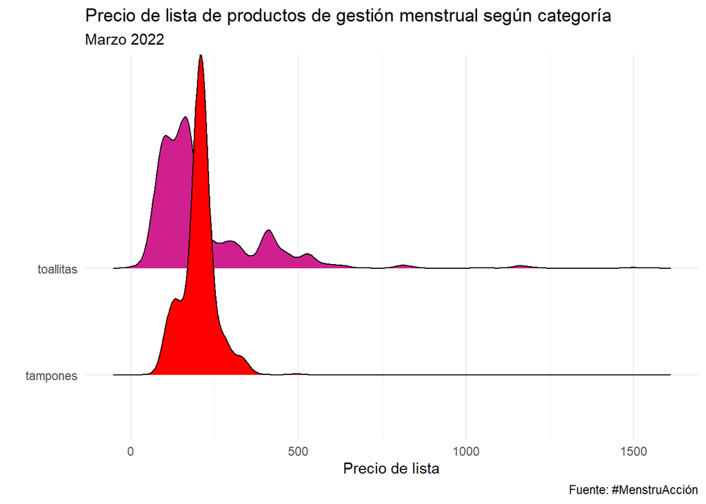

```r
datos %>%
  ggplot(., aes(x = Precio.de.lista, y = Categoría, fill = Categoría)) +
  geom_density_ridges(scale = 3, bandwidth = 20) +
  theme_minimal() +
  scale_fill_manual(values = c("red", "violetred")) +
  theme(legend.position = "none") +
  labs(title = "Precio de lista de productos de gestión menstrual según categoría",
       subtitle = date,
       x = "Precio de lista",
       y = "",
       caption = "Fuente: #MenstruAcción")
```

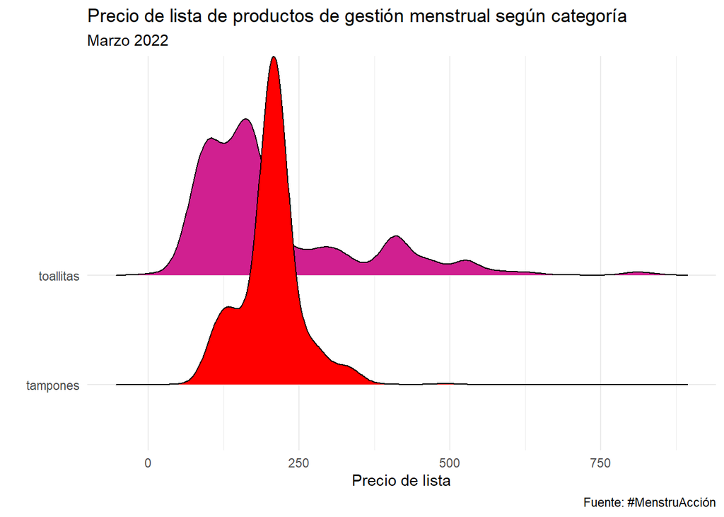

```r
# Solo en esta ocasión por los outliers presentes:

datos <- datos %>%
  filter(Precio.de.lista < 1000) #saco los outliers mayores a 1000 porque son demasiado altos.
# El resto va a ser controlado a la hora de calcular la media de precios de forma "podada"

datos %>%
  ggplot(., aes(x = Precio.de.lista, y = Categoría, fill = Categoría)) +
  geom_density_ridges(scale = 3, bandwidth = 20) +
  theme_minimal() +
  scale_fill_manual(values = c("red", "violetred")) +
  theme(legend.position = "none") +
  labs(title = "Precio de lista de productos de gestión menstrual según categoría",
       subtitle = date,
       x = "Precio de lista",
       y = "",
       caption = "Fuente: #MenstruAcción")
```

También podemos graficar los precios de cada categoría por regiones:

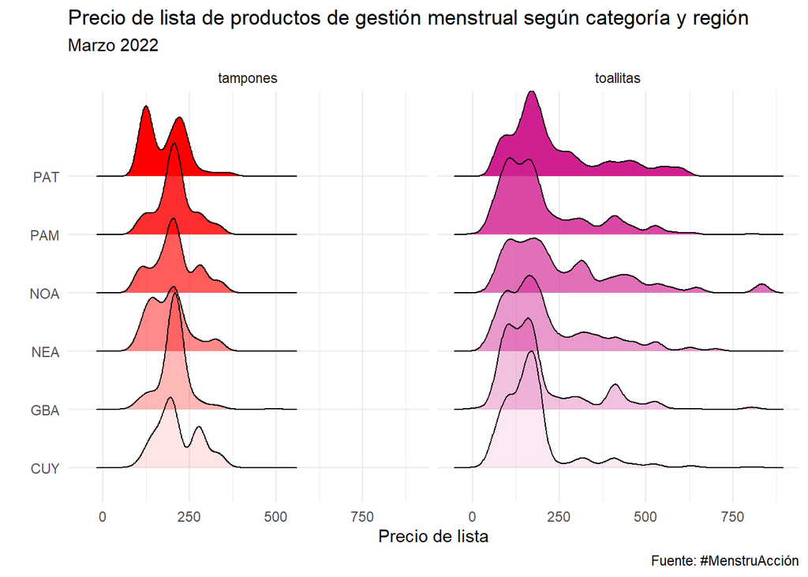

```r
datos %>%
  ggplot(., aes(x = Precio.de.lista, y = Region, fill = Categoría, alpha = Region)) +
  geom_density_ridges(scale = 2, bandwidth = 20) + # el bandwidth anterior estaba en 10
  theme_minimal() +
  scale_fill_manual(values = c("red", "violetred"))+
  facet_wrap(. ~ Categoría) +
  theme(legend.position = "none") +
  labs(title = "Precio de lista de productos de gestión menstrual según categoría y región",
       subtitle = date,
       x = "Precio de lista",
       y = "",
       caption = "Fuente: #MenstruAcción")
```

En este caso se encuentran diferencias más que nada entre los tampones, no así en el caso de las toallitas. Dado el peso de GBA entre las observaciones, tiene sentido que la distribución general se asemeje a la de dicha región.

## Limpieza de la cantidad de unidades (Presentación)

Como mencionábamos anteriormente, es necesario prestarle particular atención a la variable de `Presentación`, que indica la cantidad de unidades por cada paquete. En primer lugar, teniendo en cuenta que está expresada como “X un.”, modificamos la variable para quedarnos únicamente con las unidades en formato numérico. Esto lo hacemos convirtiendo la variable al tipo character, y luego quedándonos con aquellos caracteres entre la primer posición y aquella que se encuentra 4 posiciones por detrás de la última (omitiendo así “.0 un”). En la tabla `presentacion_nros` resumimos el comportamiento de esta nueva variable `unidades`.

```r
datos <- datos %>%
  mutate(Presentación = as.character(Presentación),
         unidades = as.numeric(substr(Presentación, 1, nchar(Presentación)-4)))

presentacion_nros <- datos %>%
  count(unidades) %>%
  arrange(-n) %>%
  mutate(porcentaje = n/sum(n),
         acumulado = cumsum(porcentaje),
         porcentaje = percent(porcentaje),
         acumulado = percent(acumulado))
presentacion_nros
```

| unidades | n | porcentaje | acumulado |
| --- | --- | --- | --- |
| 8 | 18520 | 57.355% | 57.355% |
| 16 | 8433 | 26.116% | 83.472% |
| 20 | 2262 | 7.005% | 90.477% |
| 10 | 1107 | 3.428% | 93.905% |
| 24 | 465 | 1.440% | 95.345% |
| 12 | 399 | 1.236% | 96.581% |
| 30 | 384 | 1.189% | 97.770% |
| 15 | 302 | 0.935% | 98.705% |
| 32 | 180 | 0.557% | 99.263% |
| 1 | 89 | 0.276% | 99.539% |

[output cut: 4 more lines]

Sin embargo, en la base puede verse que hay casos que, de acuerdo a la descripción en `Nombre`, tienen mal la cantidad de unidades en `Presentacion` (y por ende en unidades), afectando el calculo de precios unitarios.  
Utilizando expresiones regulares podemos quedarnos con los dígitos, sean uno o más, que están seguidos de “Un” o “un” en la variable `Nombre`. Nos quedamos con esta información en la variable `unidades_regex` y resumimos su comportamiento.

```r
datos <- datos %>%
  mutate(unidades_regex = as.numeric(str_extract(Nombre, '\\d+(?=\\s*[Uu]n?)')))

presentacion_regex <- datos %>%
  count(unidades_regex) %>%
  arrange(-n) %>%
  mutate(porcentaje = n/sum(n),
         acumulado = cumsum(porcentaje),
         porcentaje = percent(porcentaje),
         acumulado = percent(acumulado))
presentacion_regex
```

| unidades_regex | n | porcentaje | acumulado |
| --- | --- | --- | --- |
| 8 | 19063 | 59.037% | 59.037% |
| 16 | 8504 | 26.336% | 85.373% |
| 20 | 2320 | 7.185% | 92.558% |
| 10 | 1107 | 3.428% | 95.986% |
| 24 | 465 | 1.440% | 97.426% |
| 30 | 317 | 0.982% | 98.408% |
| 15 | 237 | 0.734% | 99.142% |
| 32 | 180 | 0.557% | 99.700% |
| 14 | 50 | 0.155% | 99.854% |
| 7 | 35 | 0.108% | 99.963% |

[output cut: 1 more lines]

Nótese que hay pequeñas diferencias respecto del cuadro anterior (en las 30 unidades por ejemplo). En este caso, las unidades se encuentran más concentradas en valores populares. Podemos identificar cuándo ambas informaciones (la contenida en `unidades` y en `unidades_regex`) coinciden y cuándo no. Creamos la variable `igual` que toma valor TRUE cuando son iguales, y FALSE cuando no. A continuación, en la tabla `comparo_unidades` se realiza un conteo de observaciones para ambas variables, se identifican las situaciones de coincidencia y diferencia y se ordenan los datos para ver primero las diferencias, según la magnitud.

```r
datos <- datos %>%
  mutate(igual = case_when(unidades == unidades_regex ~ T,
                           unidades != unidades_regex ~ F))

comparo_unidades <- datos %>%
  count(unidades, unidades_regex) %>%
  mutate(igual = case_when(unidades == unidades_regex ~ T,
                           unidades != unidades_regex ~ F)) %>%
  arrange(igual, -n)

comparo_unidades
```

| unidades | unidades_regex | n | igual |
| --- | --- | --- | --- |
| 12 | 8 | 341 | FALSE |
| 30 | 8 | 107 | FALSE |
| 54 | 8 | 66 | FALSE |
| 15 | 16 | 65 | FALSE |
| 12 | 20 | 58 | FALSE |
| 1 | 30 | 40 | FALSE |
| 1 | 16 | 25 | FALSE |
| 16 | 8 | 17 | FALSE |
| 1 | 8 | 14 | FALSE |
| 16 | 14 | 6 | FALSE |

[output cut: 13 more lines]

En particular, hay casos que fueron informados como de 1 o 16 unidades y en realidad eran de 8 (tiene sentido que este último sea el verdadero valor), casos que fueron informados como de 1 o 27 unidades y en realidad eran de 16, o casos que fueron informados como de 1 unidad y en realidad eran de 30, etc. Como puede verse a continuación, hay en total 743 casos en que la información no coincide, lo que representa el 2.3% de la información (empeoró considerablemente respecto del último relevamiento), y sólo 12 casos en que no había información sobre la cantidad de unidades en la descripción del artículo.

```r
datos %>%
  group_by(igual) %>%
  summarise(n = n()) %>%
  mutate(porc = percent(n/sum(n)))
```

| igual | n | porc |
| --- | --- | --- |
| FALSE | 743 | 2.3% |
| TRUE | 31535 | 97.7% |
| NA | 12 | 0.0% |

Vale la pena destacar que estos errores corresponden a todas las regiones, mayormente concentrados en GBA, y en 5 marcas diferentes.

```r
# Distribucion de los datos que queremos sacar entre las regiones
datos %>%
  filter(igual == FALSE) %>%
  count(Region)
```

| Region | n |
| --- | --- |
| CUY | 19 |
| GBA | 444 |
| NEA | 14 |
| NOA | 54 |
| PAM | 61 |
| PAT | 151 |

```r
# Distribucion de los datos que queremos sacar entre las marcas
datos %>%
  filter(igual == FALSE) %>%
  count(Marca)
```

| Marca | n |
| --- | --- |
| KOTEX | 4 |
| LADYSOFT | 112 |
| NOSOTRAS | 559 |
| O.B. | 58 |
| SIEMPRE LIBRE | 10 |

### Aclaración

En un ejercicio anterior (septiembre 2019), prescindimos de los valores faltantes en `unidades_regex` (por más que tengan valor en `unidades`, aquella que surge de la variable `Presentación`). Verificamos aquellos casos en que `unidades_regex` (que surge del texto en `Nombre`) no coincide con la variable `unidades`, y establecimos que las cantidades referidas a las unidades por paquete parecen ser mejor captadas con el método de regex sobre el texto del `Nombre` del producto, respecto de lo surgido de la información de la página como `Presentación`. Nos quedamos con `unidades_regex` para calcular el precio por unidad de los productos.

Esta vez, dado que el porcentaje de aquellos casos en que no coinciden `unidades` y `unidades_regex`, junto a los casos en que `unidades_regex` figura como `NA`, alcanzan solamente un 2.3%, se prescindirá de ellos.

```r
datos <- datos %>%
  filter(igual == TRUE)
```

```r
# Descarto las variables que no voy a usar
datos <- datos %>%
  select(-Presentación, -unidades_regex, -igual)
```

## Cálculo del precio por unidad

Creo la variable `precio_unidad`, dividiendo el `Precio.de.lista` por las `unidades`.

```r
datos <- datos %>%
  mutate(precio_unidad = round(Precio.de.lista/unidades, 2))
```

## Gráficos del precio por unidad

Ahora podemos observar la distribución de esta nueva variable con los mismos gráficos que utilizamos antes.

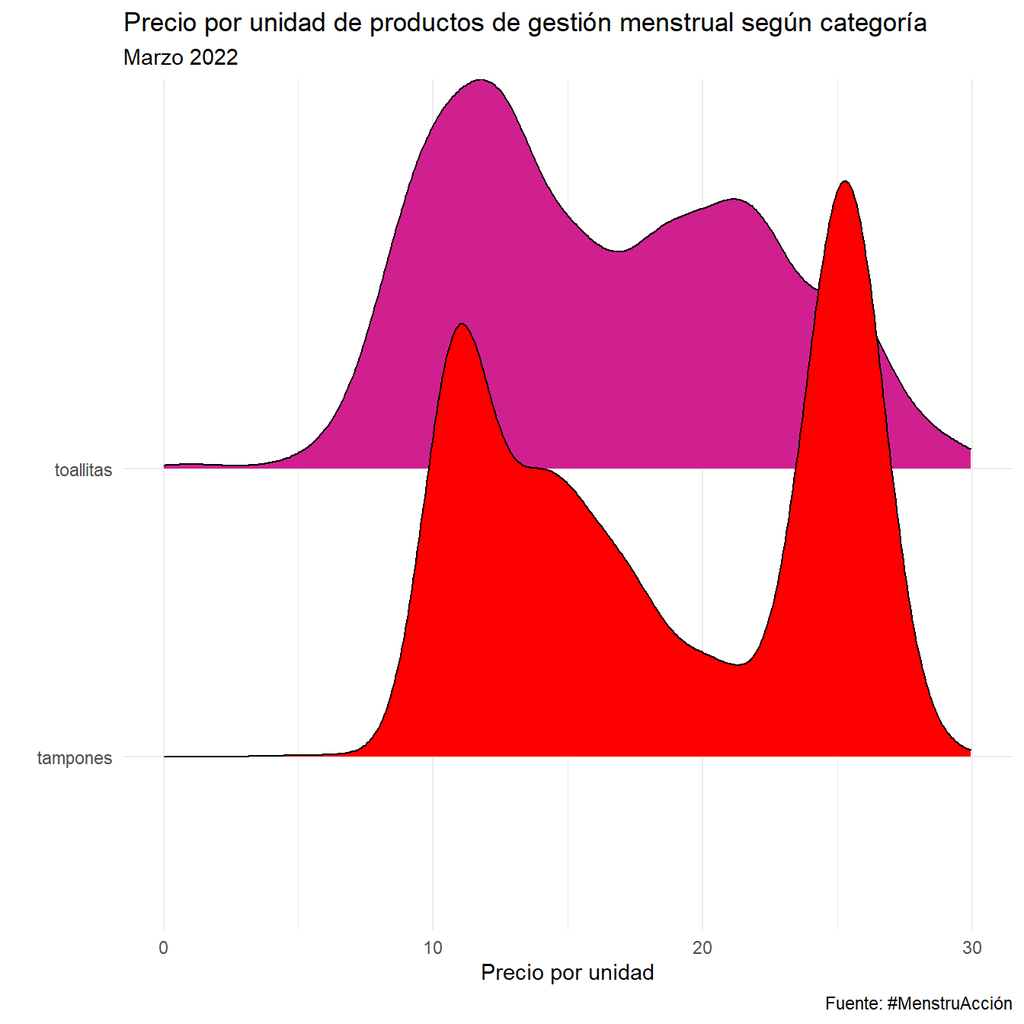

```r
ggplot(datos, aes(x = precio_unidad, y = Categoría, fill = Categoría)) +
  geom_density_ridges(scale = 2, bandwidth = 1.25) + # el bandwidth anterior estaba en 10
  theme_minimal() +
  scale_x_continuous(limits = c(0, 30)) + # En el anterior el limite estaba en 20
  scale_fill_manual(values = c("red", "violetred")) +
  theme(legend.position = "none") +
  labs(title = "Precio por unidad de productos de gestión menstrual según categoría",
       subtitle = date,
       x = "Precio por unidad",
       y = "",
       caption = "Fuente: #MenstruAcción")
```

Esta vez, para realizar el gráfico por categorías y regiones, podemos ordenar a estas últimas según su precio promedio en el gráfico. Para ello construimos un vector que las aloje en orden, llamado `reg_ordenadas`. Luego, pisamos la variable `Region` en los datos para que sea de tipo factor, y el orden de la misma esté determinado según el vector previamente definido.

```r
reg_ordenadas <- datos %>%
  group_by(Region) %>%
  summarise(promedio = mean(precio_unidad)) %>%
  arrange(promedio) %$% Region

datos <- datos %>%
  mutate(Region = factor(Region, levels = reg_ordenadas))
```

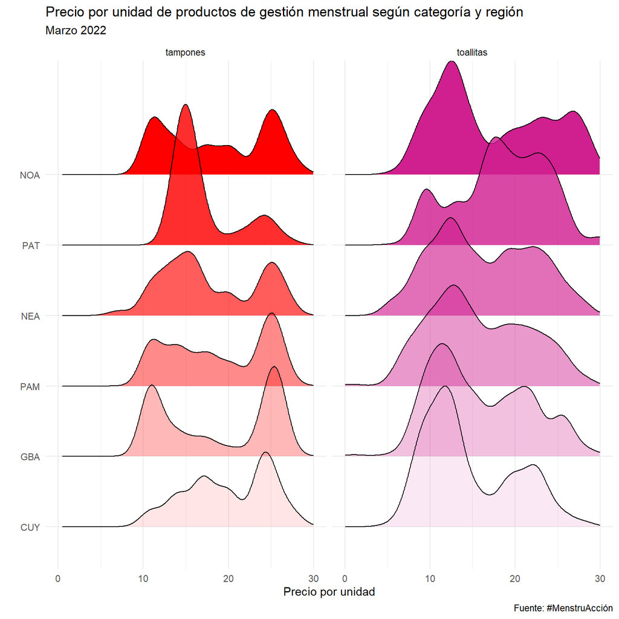

```r
ggplot(datos, aes(x = precio_unidad, y = Region, fill = Categoría, alpha = Region)) +
  geom_density_ridges(scale = 2, bandwidth = 1.25) + # el bandwidth anterior estaba en 1
  theme_minimal() +
  scale_fill_manual(values = c("red", "violetred"))+
  facet_wrap(. ~ Categoría) +
  theme(legend.position = "none") +
  scale_x_continuous(limits = c(0, 30)) + # Este valor se actualiza segun inflacion, a ojo
  labs(title = "Precio por unidad de productos de gestión menstrual según categoría y región",
       subtitle = date,
       x = "Precio por unidad",
       y = "",
       caption = "Fuente: #MenstruAcción")
```

## 2,5 % de los extremos de la distribución

Adicionalmente, como el cálculo lo realizaremos agregando los precios de acuerdo a una media alpha podada con alpha = 2,5% (o sea, ignorando los valores superiores e inferiores para evitar la intrusión de outliers a pesar de la limpieza), presentamos gráficos que justamente muestran las “colas” de la distribución que se estarían obviando.

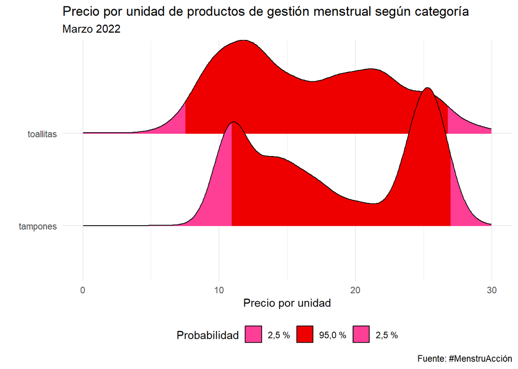

```r
ggplot(datos, aes(x = precio_unidad, y = Categoría, fill = factor(..quantile..))) +
  stat_density_ridges(geom = "density_ridges_gradient",
                      calc_ecdf = TRUE, quantiles = c(0.025, 0.975),
                      bandwidth = 1.25, scale = 1.5) + # El bandwidth anterior estaba en 0.75
  scale_fill_manual(name = "Probabilidad",
                    values = c("violetred1", "red2", "violetred1"),
                    labels = c("2,5 %", "95,0 %", "2,5 %")) +
  scale_x_continuous(limits = c(0, 30)) + # El limite anterior estaba en 20
  theme_minimal() +
  theme(legend.position = "bottom") +
  labs(title = "Precio por unidad de productos de gestión menstrual según categoría",
       subtitle = paste(date),
       x = "Precio por unidad",
       y = "",
       caption = "Fuente: #MenstruAcción")
```

Realizamos el mismo gráfico por cada provincia, ya que esa será la primer unidad de agregación para el cálculo total a nivel nacional.

```r
prov_ordenadas <- datos %>%
  group_by(Provincia) %>%
  summarise(promedio = mean(precio_unidad)) %>%
  arrange(promedio) %$%
  Provincia

datos <- datos %>%
  mutate(Provincia = factor(Provincia, levels = prov_ordenadas))
```

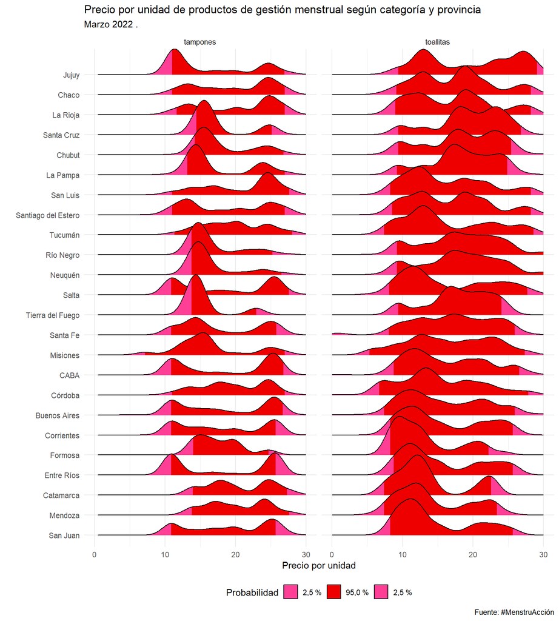

```r
ggplot(datos, aes(x = precio_unidad, y = Provincia,
                  fill = factor(..quantile..))) +
  stat_density_ridges(geom = "density_ridges_gradient",
                      calc_ecdf = TRUE, quantiles = c(0.025, 0.975),
                      bandwidth = 1.25, scale = 2) +
  scale_fill_manual(name = "Probabilidad",
                    values = c("violetred1", "red2", "violetred1"),
                    labels = c("2,5 %", "95,0 %", "2,5 %")) +
  scale_x_continuous(limits = c(0, 30)) + # El limite anterior estaba en 20
  facet_wrap(. ~ Categoría) +
  theme_minimal() +
  theme(legend.position = "bottom") +
  labs(title = "Precio por unidad de productos de gestión menstrual según categoría y provincia",
       subtitle = paste(date, ". "),
       x = "Precio por unidad",
       y = "",
       caption = "Fuente: #MenstruAcción")
```

## Apéndice: Precios iguales a cero

En esta ocasión, no hay precios iguales a cero, con lo que se prescinde de dicho análisis.

Finalmente, guardamos esta nueva versión del dataset en formato .RDS para continuar en el siguiente script con el cálculo de cuánto cuesta menstruar.

```r
saveRDS(datos, file = "Fuentes/precios-gestion-menstrual-2022-03-13-limpio.RDS")
```